# Speed Up

ROBINE Thomas

05/06/2020

The purpose of this document is to format the results of the Speedup tests performed in order to know the optimal number of cpus to have the smallest run time when estimating parameters. For these tests, we had to estimate the parameters of 14 Usms. We had to repeat the minimization 10 times and we had to evaluate the minimized criterion a 1000 times. For these tests, we had to tests two methods. The first one was to use threads and the second was to use a sequential method. Each test for each test was repeted 3 times.

# I. Thread method

| Cpus number | Run 1 | Run 2 | Run 3 | Mean time |
| --- | --- | --- | --- | --- |
| 1 | 46 hours | 46 hours | 22 hours | 38 hours |
| 2 | 13 hours | 13 hours | 13 hours | 13 hours |
| 4 | 10 hours | 10 hours | 5 hours | 8 hours |
| 6 | 4 hours | 4 hours | 4 hours | 4 hours |
| 7 | 3.5 hours | 3.5 hours | 3.5 hours | 3.5 hours |
| 8 | 3.5 hours | 3.5 hours | 3.5 hours | 3.5 hours |
| 10 | 4 hours | 4 hours | 4 hours | 4 hours |
| 12 | 4 hours | 4 hours | 4 hours | 4 hours |
| 14 | 4 hours | 4 hours | 4 hours | 4 hours |

```
## Average run time chart according to the number of CPUs
```

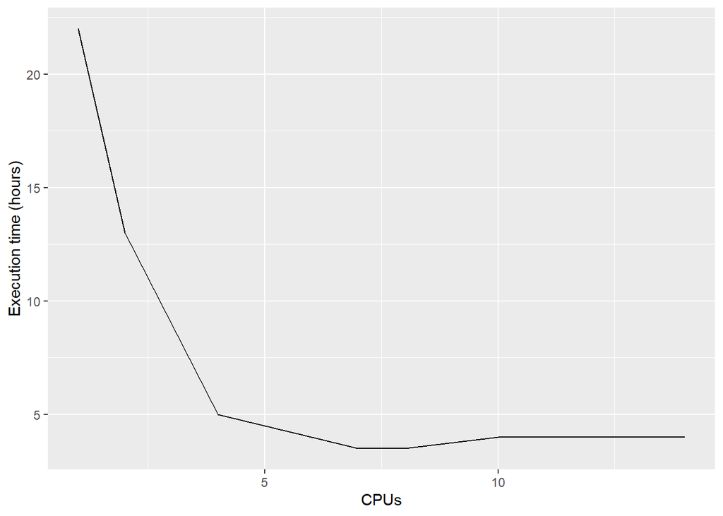

We have singular values for the runs with 1 and 4 CPUs. This may be due to a bottleneck effect when the processors are communicating with the disk. We are using the minimum run time for these cases because the other values are outlayers. To overcome this, we should have run the tests on a private node or run more tests but we couldn't. We've also could run the tests with differents parameters to optimize. However, the results are quite stable and correspond to what we could determine by experience before.

# II. Sequential method

| Cpus number | Run 1 | Run 2 | Run 3 | Mean time |
| --- | --- | --- | --- | --- |
| 1 | 12 hours | 12 hours | 12 hours | 12 hours |

We get a strange result because the logic would like the execution time to be the same as the time taken for 1 CPU with a thread method. This challenges our results and encourages us to repeat the tests with more repetitions.

# III. Speed-Up

The Speed-up formula S(p) is S(p) = Tp(1)/Tp(P), with p the nomber of processors and Tp the run time for p processors. First, we must define our S(1), which is the best time we have for 1 cpu between the thread method and the sequential method. S(1) = 12

[output not shown]

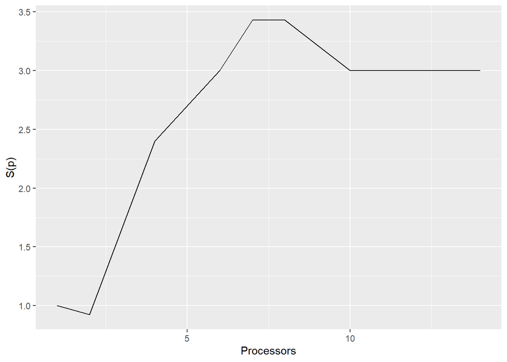